# Algorytm mrówkowy w sortowanie tablicy

```r
source("mrowki.sort.tests.r")
```

Zastosowanie algorytmu mrówkowego do problemu sortowania tablicy z różnymi parametrami algorytmu (ilość mrówek, początkowa wielkość feromonów, współczynnik degradacji feromonów) oraz różnej instancji problemu

## 1. Wielkosc problemu 5

1.1 Test 1:

- Ilość mrówek = 1,
- współczynnik degradacji 0.9,
- startowe feromony 0.5

```r
mrowki.sort.test(5, 1, 0.9, 0.5)
```

```
## [1] "Sortujemy!"
## [1]  1.898 -4.346 -1.815 -3.887 -3.984
## [1] "=============="
## [1] -4.346 -3.984 -3.887 -1.815  1.898
## [1] "Sortujemy!"
## [1]  4.6523  0.2263  1.9595 -1.4292  4.0722
## [1] "=============="
## [1] -1.4292  0.2263  1.9595  4.0722  4.6523
## [1] "Sortujemy!"
## [1] -4.7956  0.1731  5.8974  0.3286  7.1830
## [1] "=============="
## [1] -4.7956  0.1731  0.3286  5.8974  7.1830
## [1] "Sortujemy!"
## [1] -6.1532 -7.4457 -9.5507 -0.5279  3.9150
## [1] "=============="
```

[output cut: 25 more lines]

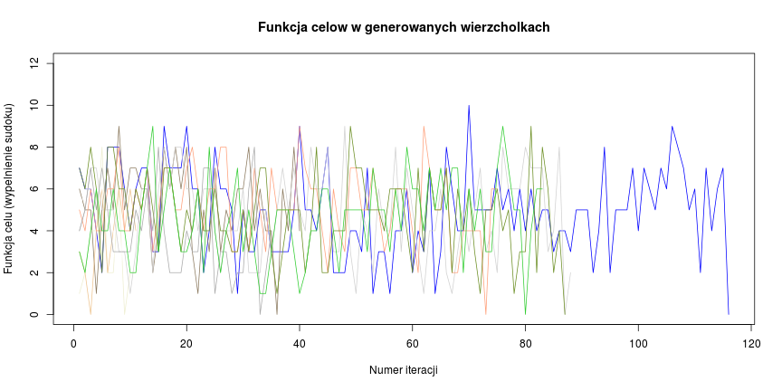

1.2 Test 2:

- Ilość mrówek = 2,
- współczynnik degradacji 0.9,
- startowe feromony 0.5

```r
mrowki.sort.test(5, 2, 0.9, 0.5)
```

```
## [1] "Sortujemy!"
## [1]  2.265  1.492 -2.886 -3.940 -6.486
## [1] "=============="
## [1] -6.486 -3.940 -2.886  1.492  2.265
## [1] "Sortujemy!"
## [1] -2.559  1.727 -4.322 -8.567  3.848
## [1] "=============="
## [1] -8.567 -4.322 -2.559  1.727  3.848
## [1] "Sortujemy!"
## [1] -9.288 -2.879 -1.692 -2.306  7.618
## [1] "=============="
## [1] -9.288 -2.879 -2.306 -1.692  7.618
## [1] "Sortujemy!"
## [1]  9.707  9.904 -2.579  5.834  1.654
## [1] "=============="
```

[output cut: 25 more lines]

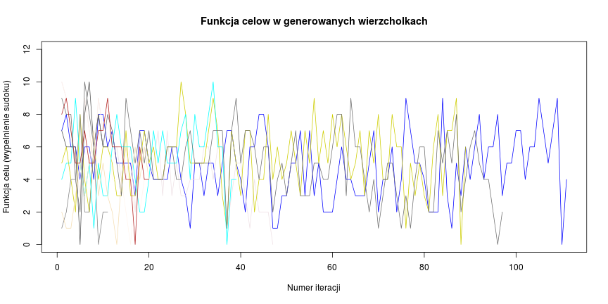

1.3 Test 3:

- Ilość mrówek = 4,
- współczynnik degradacji 0.9,
- startowe feromony 0.5

```r
mrowki.sort.test(5, 4, 0.9, 0.5)
```

```
## [1] "Sortujemy!"
## [1]  6.998  5.028 -1.748  9.370 -1.782
## [1] "=============="
## [1] -1.782 -1.748  5.028  6.998  9.370
## [1] "Sortujemy!"
## [1]  5.761 -1.950  1.687  4.564 -2.184
## [1] "=============="
## [1] -2.184 -1.950  1.687  4.564  5.761
## [1] "Sortujemy!"
## [1]  3.8637 -0.6023 -1.8259 -0.9656 -0.9862
## [1] "=============="
## [1] -1.8259 -0.9862 -0.9656 -0.6023  3.8637
## [1] "Sortujemy!"
## [1] -8.0771 -6.1164 -0.8298  8.1080  4.8522
## [1] "=============="
```

[output cut: 25 more lines]

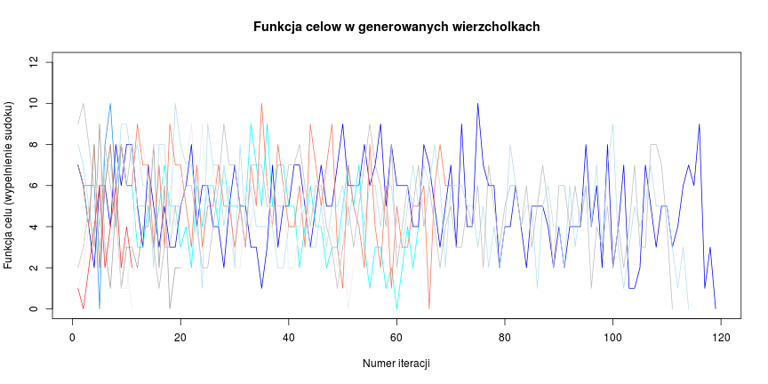

1.4 Test 4:

- Ilość mrówek = 10,
- współczynnik degradacji 0.9,
- startowe feromony 0.5

```r
mrowki.sort.test(5, 10, 0.9, 0.5)
```

```
## [1] "Sortujemy!"
## [1] -4.031 -9.521  9.370  3.204  9.384
## [1] "=============="
## [1] -9.521 -4.031  3.204  9.370  9.384
## [1] "Sortujemy!"
## [1] -4.7892  5.3739 -8.7007 -6.7477 -0.2093
## [1] "=============="
## [1] -8.7007 -6.7477 -4.7892 -0.2093  5.3739
## [1] "Sortujemy!"
## [1] -0.2839 -1.5773 -2.3172  3.3473  9.6803
## [1] "=============="
## [1] -2.3172 -1.5773 -0.2839  3.3473  9.6803
## [1] "Sortujemy!"
## [1]  4.673  3.955  5.466  6.349 -5.508
## [1] "=============="
```

[output cut: 25 more lines]

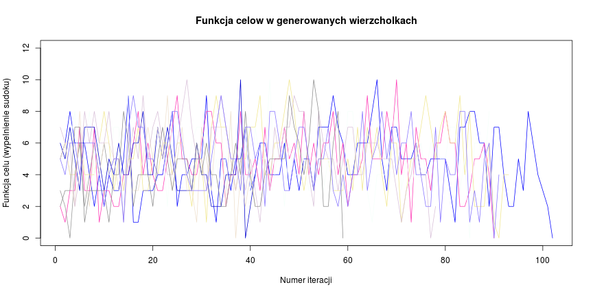

1.5 Test 5:

- Ilość mrówek = 2,
- współczynnik degradacji 0.9,
- startowe feromony 0.5

```r
mrowki.sort.test(5, 2, 0.9, 0.5)
```

```
## [1] "Sortujemy!"
## [1] -8.7719 -0.5307 -1.8446  8.2551  1.3264
## [1] "=============="
## [1] -8.7719 -1.8446 -0.5307  1.3264  8.2551
## [1] "Sortujemy!"
## [1] -2.502  8.347  4.206 -5.473  5.723
## [1] "=============="
## [1] -5.473 -2.502  4.206  5.723  8.347
## [1] "Sortujemy!"
## [1] -3.204 -3.741  7.167 -8.602  9.690
## [1] "=============="
## [1] -8.602 -3.741 -3.204  7.167  9.690
## [1] "Sortujemy!"
## [1] -8.6230  1.0435  0.4974  4.6051  4.1098
## [1] "=============="
```

[output cut: 25 more lines]

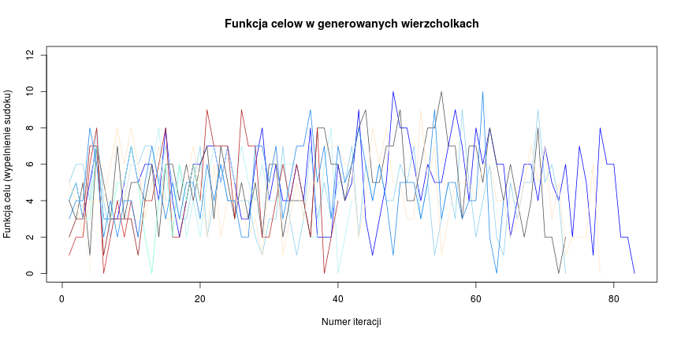

1.6 Test 6:

- Ilość mrówek = 2,
- współczynnik degradacji 0.75,
- startowe feromony 0.5

```r
mrowki.sort.test(5, 2, 0.75, 0.5)
```

```
## [1] "Sortujemy!"
## [1] -5.5537  0.5286 -8.2386 -4.2931 -6.3066
## [1] "=============="
## [1] -8.2386 -6.3066 -5.5537 -4.2931  0.5286
## [1] "Sortujemy!"
## [1] -0.8645  1.7391  4.8038  5.4590 -3.4665
## [1] "=============="
## [1] -3.4665 -0.8645  1.7391  4.8038  5.4590
## [1] "Sortujemy!"
## [1] 3.948 5.858 1.588 3.973 1.491
## [1] "=============="
## [1] 1.491 1.588 3.948 3.973 5.858
## [1] "Sortujemy!"
## [1]  6.553 -7.866 -2.745  0.539 -5.943
## [1] "=============="
```

[output cut: 25 more lines]

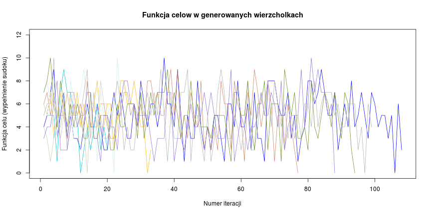

1.7 Test 7:

- Ilość mrówek = 2,
- współczynnik degradacji 0.5,
- startowe feromony 0.5

```r
mrowki.sort.test(5, 2, 0.5, 0.5)
```

```
## [1] "Sortujemy!"
## [1] 7.8898 8.2411 0.4374 8.2347 1.0245
## [1] "=============="
## [1] 0.4374 1.0245 7.8898 8.2347 8.2411
## [1] "Sortujemy!"
## [1] -2.750  1.563 -5.982  2.444  9.416
## [1] "=============="
## [1] -5.982 -2.750  1.563  2.444  9.416
## [1] "Sortujemy!"
## [1]  8.851  4.752 -3.480 -9.184 -7.727
## [1] "=============="
## [1] -9.184 -7.727 -3.480  4.752  8.851
## [1] "Sortujemy!"
## [1]  3.21039 -9.41869 -5.05075 -0.05631  1.52256
## [1] "=============="
```

[output cut: 25 more lines]

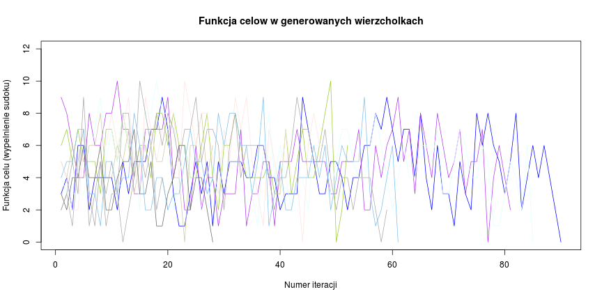

1.8 Test 8:

- Ilość mrówek = 2,
- współczynnik degradacji 0.25,
- startowe feromony 0.5

```r
mrowki.sort.test(5, 2, 0.25, 0.5)
```

```
## [1] "Sortujemy!"
## [1]  1.186  2.408 -1.954 -6.217 -2.764
## [1] "=============="
## [1] -6.217 -2.764 -1.954  1.186  2.408
## [1] "Sortujemy!"
## [1]  0.8683 -2.9833  3.3877 -9.5567  1.1112
## [1] "=============="
## [1] -9.5567 -2.9833  0.8683  1.1112  3.3877
## [1] "Sortujemy!"
## [1]  1.2718  7.0806 -0.5425 -9.1246  3.1577
## [1] "=============="
## [1] -9.1246 -0.5425  1.2718  3.1577  7.0806
## [1] "Sortujemy!"
## [1]  3.310  8.746 -8.097 -4.263 -4.729
## [1] "=============="
```

[output cut: 25 more lines]

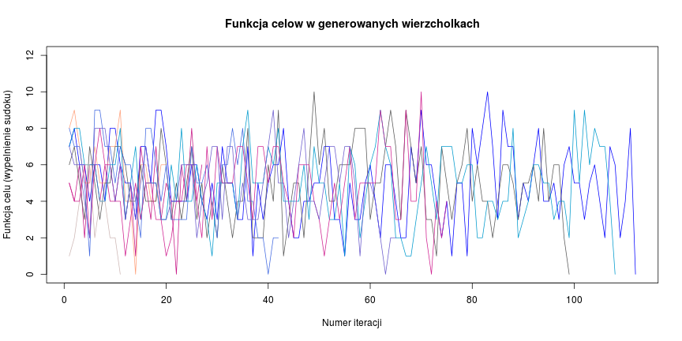

1.9 Test 9:

```r
mrowki.sort.test(5, 1, 0.5, 0.9)
```

```
## [1] "Sortujemy!"
## [1]  9.683 -1.625  1.375  9.720  3.178
## [1] "=============="
## [1] -1.625  1.375  3.178  9.683  9.720
## [1] "Sortujemy!"
## [1] -6.363 -3.284 -1.094 -5.554  8.790
## [1] "=============="
## [1] -6.363 -5.554 -3.284 -1.094  8.790
## [1] "Sortujemy!"
## [1]  0.7432 -0.7501  3.4316  1.0240 -3.0354
## [1] "=============="
## [1] -3.0354 -0.7501  0.7432  1.0240  3.4316
## [1] "Sortujemy!"
## [1]  4.859  7.301  8.140 -8.901  8.441
## [1] "=============="
```

[output cut: 25 more lines]

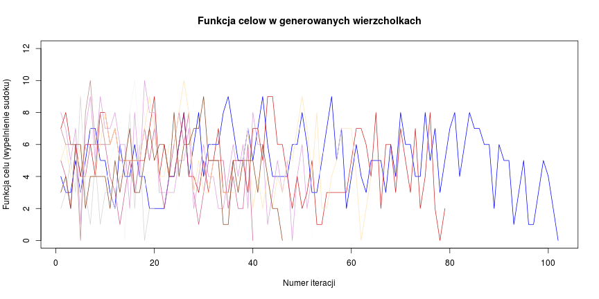

1.10 Test 10:

- Ilość mrówek = 2,
- współczynnik degradacji 0.5,
- startowe feromony 0.75

```r
mrowki.sort.test(5, 2, 0.5, 0.75)
```

```
## [1] "Sortujemy!"
## [1] 4.597 5.752 1.420 9.733 3.733
## [1] "=============="
## [1] 1.420 3.733 4.597 5.752 9.733
## [1] "Sortujemy!"
## [1]  9.552  3.798 -3.024 -9.293 -1.518
## [1] "=============="
## [1] -9.293 -3.024 -1.518  3.798  9.552
## [1] "Sortujemy!"
## [1]  2.536  5.169 -4.961  3.398 -9.112
## [1] "=============="
## [1] -9.112 -4.961  2.536  3.398  5.169
## [1] "Sortujemy!"
## [1] -1.512  5.393  7.072 -2.675 -3.077
## [1] "=============="
```

[output cut: 25 more lines]

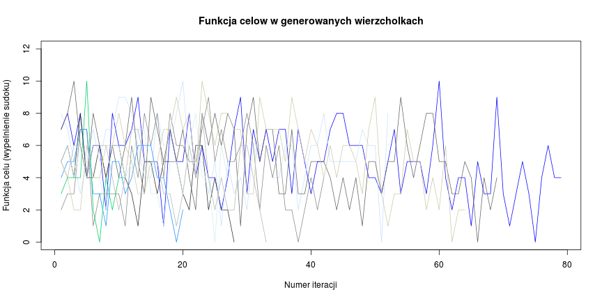

1.11 Test 11:

- Ilość mrówek = 2,
- współczynnik degradacji 0.5,
- startowe feromony 0.5

```r
mrowki.sort.test(5, 2, 0.5, 0.5)
```

```
## [1] "Sortujemy!"
## [1]  9.170 -4.365 -1.309  8.120  5.300
## [1] "=============="
## [1] -4.365 -1.309  5.300  8.120  9.170
## [1] "Sortujemy!"
## [1]  8.268 -8.549  1.615 -9.878  8.424
## [1] "=============="
## [1] -9.878 -8.549  1.615  8.268  8.424
## [1] "Sortujemy!"
## [1]  0.1638  2.9369  9.7136 -2.5308 -0.2626
## [1] "=============="
## [1] -2.5308 -0.2626  0.1638  2.9369  9.7136
## [1] "Sortujemy!"
## [1]  0.06432 -2.25716  0.36627  1.87605 -6.08225
## [1] "=============="
```

[output cut: 25 more lines]

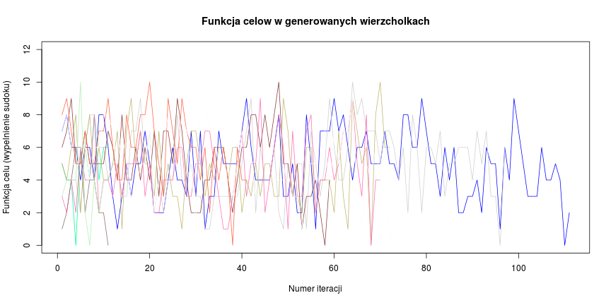

1.12 Test 12:

- Ilość mrówek = 2,
- współczynnik degradacji 0.5,
- startowe feromony 0.25

```r
mrowki.sort.test(5, 2, 0.5, 0.25)
```

```
## [1] "Sortujemy!"
## [1] -0.3836 -7.7787 -2.9722  0.1381  7.5932
## [1] "=============="
## [1] -7.7787 -2.9722 -0.3836  0.1381  7.5932
## [1] "Sortujemy!"
## [1]  5.212  7.272  1.057 -2.181  9.303
## [1] "=============="
## [1] -2.181  1.057  5.212  7.272  9.303
## [1] "Sortujemy!"
## [1] -6.487  4.997  9.707 -6.288  5.958
## [1] "=============="
## [1] -6.487 -6.288  4.997  5.958  9.707
## [1] "Sortujemy!"
## [1]  1.3189  3.6780 -4.3953  0.8324  1.1186
## [1] "=============="
```

[output cut: 25 more lines]

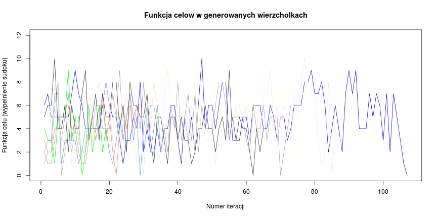